# Final Project: US Traffic Congestion Analysis 2016-2022

STAT 230 Spring 2025

Authors

Darryl Carpenter

Derek Riera

Faith Puppala

Michael Ogbuehi

## Data

The dataset used in this project was sourced from Kaggle and contains U.S. traffic congestion data from 2016 to 2022. It includes detailed records of congestion events, weather conditions, and location metadata timestamps, and traffic delays.

```r
#Load necessary libraries
library(tidyverse)
library(lubridate)
library(usmap)
library(ggplot2)


#Load dataset
congestions <- read_csv("Data/us_congestion_2016_2022_sample_2m.csv",
                        col_types = cols(
                          Severity = col_double(),
                          StartTime = col_datetime(format = ""),
                          EndTime = col_datetime(format = ""),
                          State = col_factor(),
                          Weather_Conditions = col_factor()
                        ))

#Check for missing or failed-to-parse data
failed_dates <- sum(is.na(congestions$StartTime))
failed_severity <- sum(is.na(congestions$Severity))

#Print failed counts
print(paste("Failed to parse StartTime:", failed_dates, "rows"))
```

```
[1] "Failed to parse StartTime: 1823 rows"
```

```r
print(paste("Missing Severity values:", failed_severity, "rows"))
```

```
[1] "Missing Severity values: 0 rows"
```

```r
#Remove rows with missing timestamps, severity, or state
congestions_clean <- congestions |> drop_na(StartTime, EndTime, Severity, State)

#Count occurrences of each severity level after cleaning
severity_counts_clean <- congestions_clean |>
  group_by(Severity) |>
  summarize(Count = n(), .groups = "drop") |>
  arrange(Severity)

#Print severity counts after cleaning
print(severity_counts_clean)
```

```
# A tibble: 5 × 2
  Severity  Count
     <dbl>  <int>
1        0 484551
2        1 933136
3        2 524357
4        3  56124
5        4      9
```

```r
#Preview cleaned dataset
glimpse(congestions_clean)
```

```
Rows: 1,998,177
Columns: 30
$ ID                              <chr> "C-14344128", "C-32285069", "C-1421364…
$ Severity                        <dbl> 2, 0, 0, 0, 1, 1, 2, 1, 1, 2, 0, 2, 2,…
$ Start_Lat                       <dbl> 39.19103, 41.73602, 32.51904, 40.73056…
$ Start_Lng                       <dbl> -120.81974, -87.72156, -93.74110, -74.…
$ StartTime                       <dttm> 2016-12-21 00:19:00, 2018-11-16 22:18…
$ EndTime                         <dttm> 2016-12-21 00:33:47, 2018-11-16 23:08…
$ `Distance(mi)`                  <dbl> 1.40, 0.73, 1.80, 1.42, 2.60, 6.88, 2.…
$ `DelayFromTypicalTraffic(mins)` <dbl> 2.58, 0.42, 1.00, 1.00, 4.90, 3.00, 2.…
$ `DelayFromFreeFlowSpeed(mins)`  <dbl> 2.60, 1.00, 2.00, 2.00, 6.92, 3.00, 5.…
$ Congestion_Speed                <chr> "Moderate", "Slow", "Moderate", "Slow"…
$ Description                     <chr> "Delays of four minutes on I-80 Westbo…
$ Street                          <chr> "I-80 W", "S Pulaski Rd", "E Texas St"…
$ City                            <chr> "Dutch Flat", "Chicago", "Bossier City…
```

[output cut: 17 more lines]

The data was cleaned as follows:

- Removed rows with missing or failed-to-parse datetime (`StartTime`, `EndTime`), severity, and state values using `drop_na`.
- Ensured that date parsing was successful by checking for `NA` values in datetime columns.
- Grouped and counted severity levels post-cleaning to assess data distribution.

## Variables

| **Variable** | **Type** | **Description** |
| --- | --- | --- |
| `ID` | Categorical (String) | Unique identifier for each congestion record |
| `Severity` | Numeric (Discrete) | Congestion severity level (0 to 4) |
| `Start_Lat`, `Start_Lng` | Numeric (Continuous) | GPS coordinates where the congestion event begins |
| `StartTime`, `EndTime` | Datetime | Start and end time of congestion event |
| `Distance(mi)` | Numeric (Continuous) | Length of the congestion in miles |
| `DelayFromTypicalTraffic(mins)` | Numeric (Continuous) | Delay compared to normal traffic conditions |
| `DelayFromFreeFlowSpeed(mins)` | Numeric (Continuous) | Delay compared to free-flowing speed conditions |
| `Congestion_Speed` | Categorical (String) | Traffic speed category (e.g., Slow, Moderate, Fast) |
| `Description` | Categorical (String) | Text description of the congestion event |
| `Street`, `City`, `County`, `ZipCode`, `Country` | Categorical (String) | Location information for the event |
| `State` | Categorical (String) | U.S. state where the congestion occurred |
| `Region` | Categorical (Derived) | U.S. Census Bureau region (Northeast, Midwest, South, West) *(You’ll need to derive this column yourself based on `State`)* |
| `LocalTimeZone` | Categorical (String) | Time zone of the event |
| `WeatherStation_AirportCode` | Categorical (String) | Nearest weather station code |
| `WeatherTimeStamp` | Datetime | Time of recorded weather data |
| `Weather_Conditions` | Categorical (String) | General weather conditions (e.g., Clear, Rain, Snow) |
| `Weather_Event` | Categorical (String) | Specific weather events (e.g., Thunderstorm, Fog) |
| `Temperature(F)` | Numeric (Continuous) | Ambient temperature in Fahrenheit |
| `WindChill(F)` | Numeric (Continuous) | Wind chill temperature in Fahrenheit |
| `Humidity(%)` | Numeric (Continuous) | Percentage of humidity |
| `Pressure(in)` | Numeric (Continuous) | Atmospheric pressure in inches |
| `Visibility(mi)` | Numeric (Continuous) | Visibility distance in miles |
| `WindDir` | Categorical (String) | Wind direction (e.g., NW, SSW) |
| `WindSpeed(mph)` | Numeric (Continuous) | Wind speed in miles per hour |
| `Precipitation(in)` | Numeric (Continuous) | Amount of precipitation in inches |

## Questions

1. **Descriptive (Numeric Focused):**

   “What is the distribution of traffic congestion severity in the U.S. between 2016 and 2022, and what factors influence this distribution?”
2. **Grouped (Categorical + Numeric):**

   “How does the average congestion severity vary by state, and which states show significant differences?”

## Plots

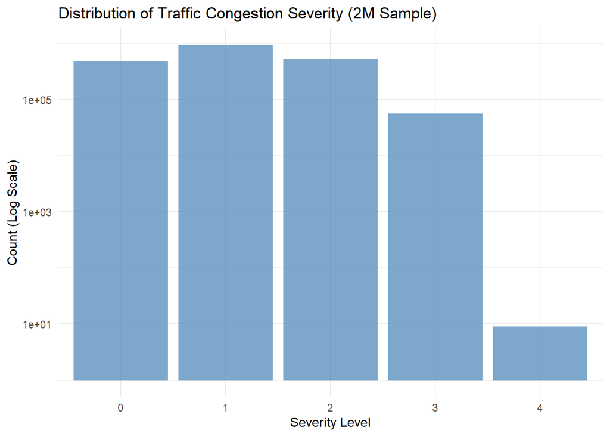

```r
congestions_clean |>
  ggplot(aes(x = factor(Severity, levels = c(0,1,2,3,4)))) +
  geom_bar(fill = "steelblue", alpha = 0.7) +
  scale_y_log10() +
  labs(title = "Distribution of Traffic Congestion Severity (2M Sample)",
       x = "Severity Level",
       y = "Count (Log Scale)") +
  theme_minimal()
```

### **Purpose of the Plot**

This histogram provides a visual summary of how traffic congestion severity levels are distributed across a sample of 2 million records from the dataset. The `Severity` variable is ordinal, ranging from **0 (least severe)** to **4 (most severe)**.

#### **Key Observations:**

1. **Severity Levels 0 to 2 Dominate**

   The majority of congestion events fall under severity levels **0, 1, and 2**, indicating that most traffic congestion events in the dataset are **low to moderate in severity**.
2. **Logarithmic Y-Axis**

   The y-axis uses a **logarithmic scale** to better visualize differences between categories, especially given the large data volume. This prevents higher frequencies (e.g., Severity 1) from overshadowing less frequent categories (e.g., Severity 4).
3. **Severity Level 4 Is Rare**

   Events with severity level **4** are **significantly less common** than all other categories. This suggests that highly severe congestion events are relatively rare, and could be considered outliers or special cases worth further analysis.
4. **Comparative Volume**

   Although the severity scale is only from 0 to 4, the counts vary greatly across these levels. **Severity 1** appears to be the most frequent, followed closely by levels 0 and 2.
5. A **right-skewed** distribution means that most of the data is concentrated on the **left side** (lower severity levels), and the **tail** extends to the **right** (toward higher severity levels).

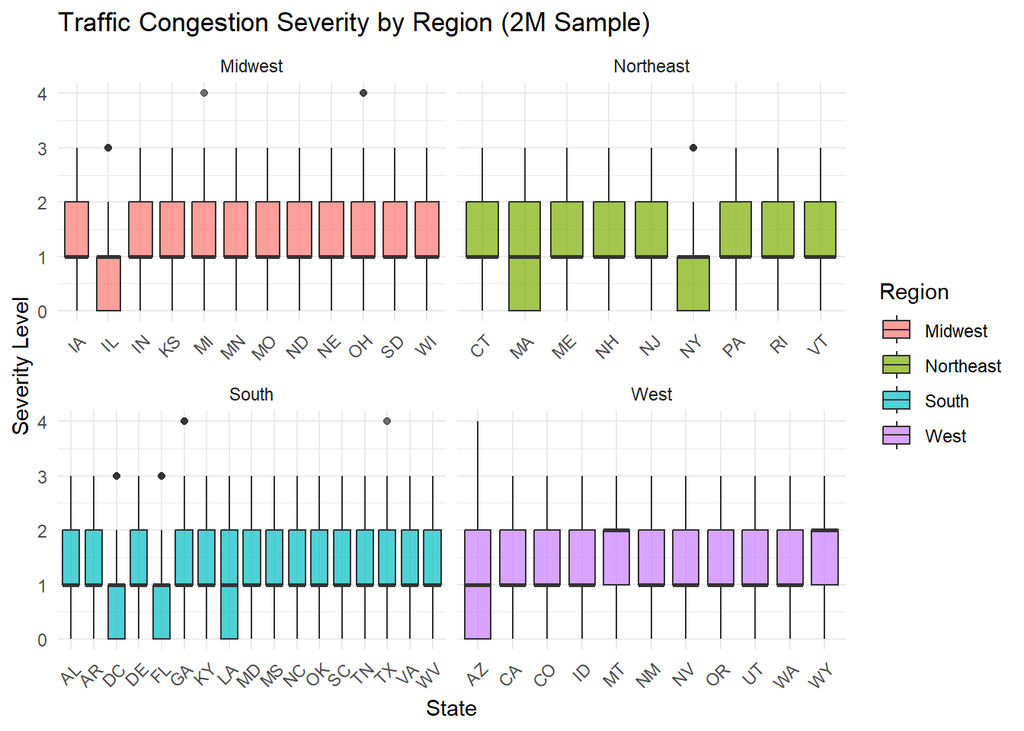

```r
# Define U.S. regions based on Census Bureau
state_regions <- tibble(
  State = c("CT", "ME", "MA", "NH", "RI", "VT", "NJ", "NY", "PA",  # Northeast
            "IL", "IN", "MI", "OH", "WI", "IA", "KS", "MN", "MO", "NE", "ND", "SD",  # Midwest
            "DE", "FL", "GA", "MD", "NC", "SC", "VA", "DC", "WV", "AL", "KY", "MS", "TN", "LA", "TX", "OK", "AR",  # South
            "AK", "AZ", "CA", "CO", "HI", "ID", "MT", "NV", "NM", "OR", "UT", "WA", "WY"),  # West
  Region = c(rep("Northeast", 9),
             rep("Midwest", 12),
             rep("South", 17),
             rep("West", 13))
)

# Merge region info
congestions_clean <- congestions_clean |>
  left_join(state_regions, by = "State")

# Box Plot - Severity by Region and State
congestions_clean |>
  ggplot(aes(x = State, y = Severity, fill = Region)) +
  geom_boxplot(alpha = 0.7) +
  facet_wrap(~ Region, scales = "free_x") +
  labs(title = "Traffic Congestion Severity by Region (2M Sample)",
       x = "State",
       y = "Severity Level",
       fill = "Region") +
  theme_minimal() +
  theme(axis.text.x = element_text(angle = 45, hjust = 1))
```

### **Purpose of the Plot**

This box plot provides a comparative analysis of **traffic congestion severity levels** across U.S. states, grouped by **Census Bureau regions** (Midwest, Northeast, South, West), based on a sample of 2 million congestion events.

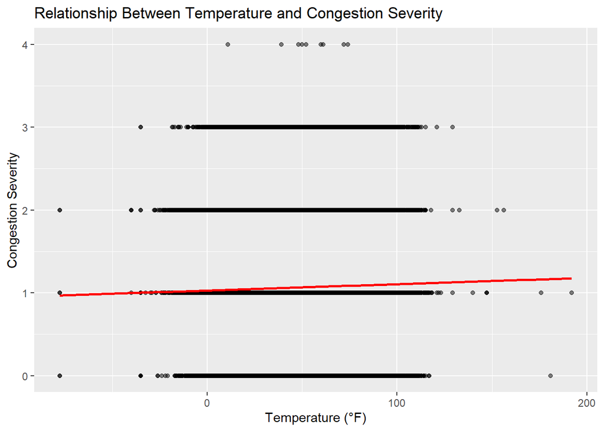

```r
# Scatter plot between Temperature and Severity
congestions_clean |>
  ggplot(aes(x = `Temperature(F)`, y = Severity)) +
  geom_point(alpha = 0.5) +
  geom_smooth(method = "lm", color = "red") +
  labs(title = "Relationship Between Temperature and Congestion Severity",
       x = "Temperature (°F)", y = "Congestion Severity")
```

## Descriptive Analysis

```r
# Summary statistics of Severity by Region
# Summary statistics of Severity by Region (no na.rm = TRUE)
congestions_clean |>
  group_by(Region) |>
  summarize(
    Mean_Severity = mean(Severity),
    SD_Severity = sd(Severity),
    Min_Severity = min(Severity),
    Max_Severity = max(Severity)
  )
```

```
# A tibble: 4 × 5
  Region    Mean_Severity SD_Severity Min_Severity Max_Severity
  <chr>             <dbl>       <dbl>        <dbl>        <dbl>
1 Midwest           1.09        0.809            0            4
2 Northeast         0.992       0.782            0            3
3 South             1.09        0.770            0            4
4 West              1.12        0.778            0            4
```

Summary statistics of congestion severity by region indicate that severity levels are generally low across all regions, with mean values hovering slightly above 1. The **West region** shows the highest average severity at approximately **1.12**, while the **Northeast** exhibits the lowest at around **0.99**. Standard deviations are relatively small (around 0.77 to 0.81), suggesting limited variability in severity within each region. The minimum severity recorded is 0 in all regions, while the maximum severity reaches 4 in the Midwest, South, and West, but only 3 in the Northeast.

## Inferential Statistics - Anova

```r
# Run ANOVA to test if Severity differs across Regions
anova_result <- aov(Severity ~ Region, data = congestions_clean)
summary(anova_result)
```

```
                 Df  Sum Sq Mean Sq F value Pr(>F)
Region            3    4508  1502.5    2466 <2e-16 ***
Residuals   1998173 1217403     0.6
---
Signif. codes:  0 '***' 0.001 '**' 0.01 '*' 0.05 '.' 0.1 ' ' 1
```

```r
# Build a linear model
model_severity <- lm(Severity ~ Region, data = congestions_clean)

# Run ANOVA on the model
anova(model_severity)
```

```
Analysis of Variance Table

Response: Severity
               Df  Sum Sq Mean Sq F value    Pr(>F)
Region          3    4508 1502.52  2466.1 < 2.2e-16 ***
Residuals 1998173 1217403    0.61
---
Signif. codes:  0 '***' 0.001 '**' 0.01 '*' 0.05 '.' 0.1 ' ' 1
```

The ANOVA table output shows:

- **F-statistic**: 2466
- **p-value**: < 2e-16

  Since the p-value is extremely small (less than 0.001), it provides strong evidence against the null hypothesis.

The results of the ANOVA test indicate that **there is a statistically significant difference in average congestion severity between regions** (F(3, 1,998,173) = 2466, p < 0.001).

Thus, we reject the null hypothesis and conclude that regional location does influence the severity of traffic congestion events.

However, while the difference is statistically significant, the practical differences in mean severity are **relatively small** (ranging between 0.99 and 1.12), suggesting that congestion severity is fairly similar across regions.

## Average Traffic Congestion Severity - Usmap

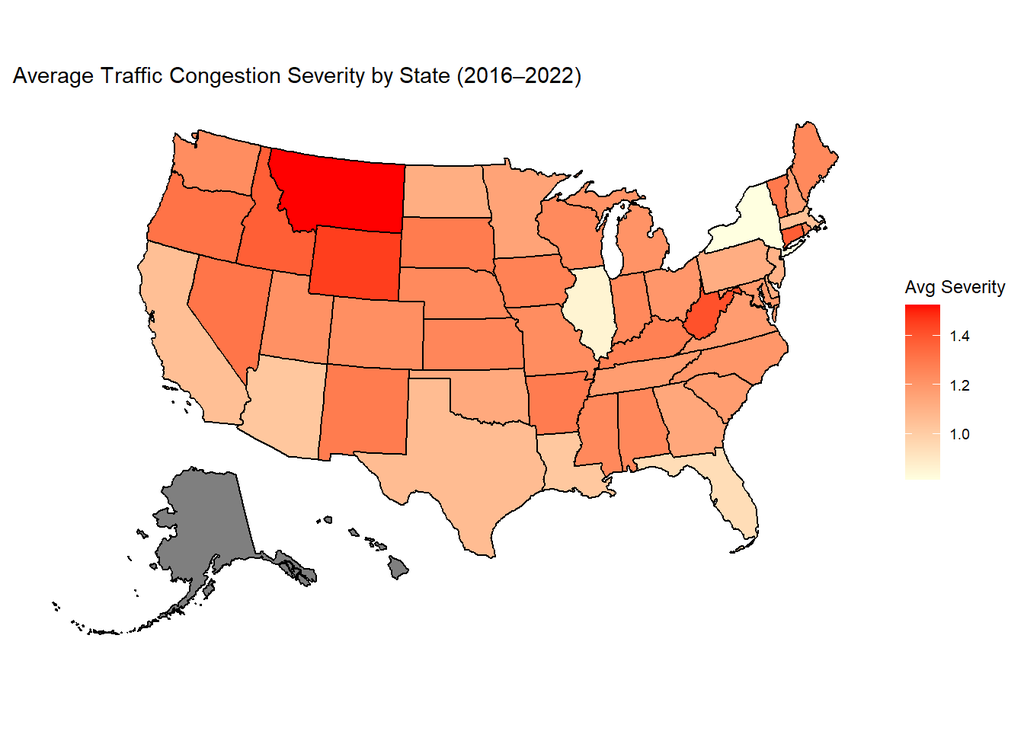

```r
#if you are running the section for the second time please comment the two lines below
congestions_clean <- congestions_clean |>
  rename(Delay_Mins = `DelayFromTypicalTraffic(mins)`)
by_state <- congestions_clean |>
  group_by(State) |>
  summarize(
    avg_severity = mean(Severity),
    total_events = n(),
    avg_delay = mean(Delay_Mins, na.rm = TRUE),
    .groups = "drop"
  ) |>
  left_join(state_regions, by = "State") |>
  mutate(state = state.name[match(State, state.abb)]) |>
  filter(!is.na(state))
# Calculate average severity per state
state_avg_severity <- congestions_clean |>
  group_by(State) |>
  summarize(avg_severity = mean(Severity, na.rm = TRUE))

# Plot choropleth map
plot_usmap(data = by_state, values = "avg_severity", regions = "states") +
  scale_fill_continuous(
    low = "lightyellow", high = "red",
    name = "Avg Severity", label = scales::comma
  ) +
  labs(title = "Average Traffic Congestion Severity by State (2016–2022)") +
  theme(legend.position = "right")
```

This US map visualizes the average traffic congestion severity per state from 2016 to 2022. While states like **Texas and California** are well-known for frequent congestion, their **average severity appears moderate rather than extreme**. This is because they have **many recorded events**, many of which fall under **mild to moderate severity (Levels 1–2).**

## Conclusion

The scatterplot between temperature and severity helped explore environmental influence, but showed no meaningful relationship, indicating that congestion severity is not strongly affected by ambient temperature. Summary statistics across regions showed slight differences in mean severity values, with the West having the highest average (around 1.12) and the Northeast the lowest (just under 1.00).

To test whether regional differences were statistically significant, an ANOVA was conducted. The p-value (< 0.001) and F-statistic (> 2400) confirmed a statistically significant difference between regions. However, the actual difference in mean severity was slight, reinforcing the need to balance statistical results with practical interpretation.

These visualizations and analyses demonstrate how combining statistical tools with clear visual communication can uncover expected patterns and deeper insights into real-world transportation data.